# Face Generation

In this project, you'll define and train a DCGAN on a dataset of faces. Your goal is to get a generator network to generate *new* images of faces that look as realistic as possible!

The project will be broken down into a series of tasks from **loading in data to defining and training adversarial networks**. At the end of the notebook, you'll be able to visualize the results of your trained Generator to see how it performs; your generated samples should look like fairly realistic faces with small amounts of noise.

### Get the Data

You'll be using the [CelebFaces Attributes Dataset (CelebA)](http://mmlab.ie.cuhk.edu.hk/projects/CelebA.html) to train your adversarial networks.

This dataset is more complex than the number datasets (like MNIST or SVHN) you've been working with, and so, you should prepare to define deeper networks and train them for a longer time to get good results. It is suggested that you utilize a GPU for training.

### Pre-processed Data

Since the project's main focus is on building the GANs, we've done *some* of the pre-processing for you. Each of the CelebA images has been cropped to remove parts of the image that don't include a face, then resized down to 64x64x3 NumPy images. Some sample data is show below.

[figure not shown]

> If you are working locally, you can download this data [by clicking here](https://s3.amazonaws.com/video.udacity-data.com/topher/2018/November/5be7eb6f_processed-celeba-small/processed-celeba-small.zip)

This is a zip file that you'll need to extract in the home directory of this notebook for further loading and processing. After extracting the data, you should be left with a directory of data `processed_celeba_small/`

```python
import signal

from contextlib import contextmanager

import requests


DELAY = INTERVAL = 4 * 60  # interval time in seconds
MIN_DELAY = MIN_INTERVAL = 2 * 60
KEEPALIVE_URL = "https://nebula.udacity.com/api/v1/remote/keep-alive"
TOKEN_URL = "http://metadata.google.internal/computeMetadata/v1/instance/attributes/keep_alive_token"
TOKEN_HEADERS = {"Metadata-Flavor":"Google"}


def _request_handler(headers):
    def _handler(signum, frame):
        requests.request("POST", KEEPALIVE_URL, headers=headers)
    return _handler


@contextmanager
def active_session(delay=DELAY, interval=INTERVAL):
    """
    Example:

    from workspace_utils import active session

    with active_session():
        # do long-running work here
    """
    token = requests.request("GET", TOKEN_URL, headers=TOKEN_HEADERS).text
    headers = {'Authorization': "STAR " + token}
    delay = max(delay, MIN_DELAY)
    interval = max(interval, MIN_INTERVAL)
    original_handler = signal.getsignal(signal.SIGALRM)
    try:
        signal.signal(signal.SIGALRM, _request_handler(headers))
        signal.setitimer(signal.ITIMER_REAL, delay, interval)
        yield
    finally:
        signal.signal(signal.SIGALRM, original_handler)
        signal.setitimer(signal.ITIMER_REAL, 0)


def keep_awake(iterable, delay=DELAY, interval=INTERVAL):
    """
    Example:

    from workspace_utils import keep_awake

    for i in keep_awake(range(5)):
        # do iteration with lots of work here
    """
    with active_session(delay, interval): yield from iterable
```

```python
# can comment out after executing
!unzip processed_celeba_small.zip
```

```
Archive:  processed_celeba_small.zip
replace processed_celeba_small/.DS_Store? [y]es, [n]o, [A]ll, [N]one, [r]ename: ^C
```

```python
data_dir = 'processed_celeba_small/'

"""
DON'T MODIFY ANYTHING IN THIS CELL
"""
import pickle as pkl
import matplotlib.pyplot as plt
import numpy as np
import problem_unittests as tests
#import helper

%matplotlib inline
```

## Visualize the CelebA Data

### Pre-process and Load the Data

Since the project's main focus is on building the GANs, we've done *some* of the pre-processing for you. Each of the CelebA images has been cropped to remove parts of the image that don't include a face, then resized down to 64x64x3 NumPy images. This *pre-processed* dataset is a smaller subset of the very large CelebA data.

> There are a few other steps that you'll need to **transform** this data and create a **DataLoader**.

#### Exercise: Complete the following `get_dataloader` function, such that it satisfies these requirements:

- Your images should be square, Tensor images of size `image_size x image_size` in the x and y dimension.
- Your function should return a DataLoader that shuffles and batches these Tensor images.

#### ImageFolder

To create a dataset given a directory of images, it's recommended that you use PyTorch's [ImageFolder](https://pytorch.org/docs/stable/torchvision/datasets.html#imagefolder) wrapper, with a root directory `processed_celeba_small/` and data transformation passed in.

```python
# necessary imports
import torch
from torchvision import datasets
from torchvision import transforms
```

```python
from torch.utils.data import DataLoader

def get_dataloader(batch_size, image_size, data_dir='processed_celeba_small/'):
    """
    Batch the neural network data using DataLoader
    :param batch_size: The size of each batch; the number of images in a batch
    :param img_size: The square size of the image data (x, y)
    :param data_dir: Directory where image data is located
    :return: DataLoader with batched data
    """

    # TODO: Implement function and return a dataloader
    transform = transforms.Compose([transforms.Resize(image_size),
                                    transforms.ToTensor()])
    dataset = datasets.ImageFolder(data_dir, transform)
    loader = DataLoader(dataset=dataset, batch_size=batch_size, shuffle=True, num_workers=0)

    return loader
```

## Create a DataLoader

#### Exercise: Create a DataLoader `celeba_train_loader` with appropriate hyperparameters.

Call the above function and create a dataloader to view images.

- You can decide on any reasonable `batch_size` parameter
- Your `image_size` **must be** `32`. Resizing the data to a smaller size will make for faster training, while still creating convincing images of faces!

```python
# Define function hyperparameters
batch_size = 16
img_size = 32

"""
DON'T MODIFY ANYTHING IN THIS CELL THAT IS BELOW THIS LINE
"""
# Call your function and get a dataloader
celeba_train_loader = get_dataloader(batch_size, img_size)
```

Next, you can view some images! You should seen square images of somewhat-centered faces.

Note: You'll need to convert the Tensor images into a NumPy type and transpose the dimensions to correctly display an image, suggested `imshow` code is below, but it may not be perfect.

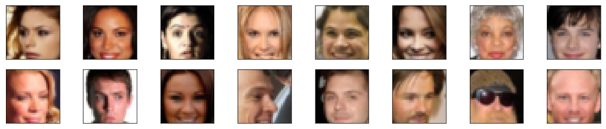

```python
# helper display function
def imshow(img):
    npimg = img.numpy()
    plt.imshow(np.transpose(npimg, (1, 2, 0)))

"""
DON'T MODIFY ANYTHING IN THIS CELL THAT IS BELOW THIS LINE
"""
# obtain one batch of training images
dataiter = iter(celeba_train_loader)
images, _ = dataiter.next() # _ for no labels

# plot the images in the batch, along with the corresponding labels
fig = plt.figure(figsize=(20, 4))
plot_size=16
for idx in np.arange(plot_size):
    ax = fig.add_subplot(2, plot_size/2, idx+1, xticks=[], yticks=[])
    imshow(images[idx])
```

#### Exercise: Pre-process your image data and scale it to a pixel range of -1 to 1

You need to do a bit of pre-processing; you know that the output of a `tanh` activated generator will contain pixel values in a range from -1 to 1, and so, we need to rescale our training images to a range of -1 to 1. (Right now, they are in a range from 0-1.)

```python
# TODO: Complete the scale function
def scale(x, feature_range=(-1, 1)):
    ''' Scale takes in an image x and returns that image, scaled
       with a feature_range of pixel values from -1 to 1.
       This function assumes that the input x is already scaled from 0-1.'''
    # assume x is scaled to (0, 1)
    # scale to feature_range and return scaled x
    min, max = feature_range
    return x * (max - min) + min
```

```python
"""
DON'T MODIFY ANYTHING IN THIS CELL THAT IS BELOW THIS LINE
"""
# check scaled range
# should be close to -1 to 1
img = images[0]
scaled_img = scale(img)

print('Min: ', scaled_img.min())
print('Max: ', scaled_img.max())
```

```
Min:  tensor(-0.9922)
Max:  tensor(0.9373)
```

# Define the Model

A GAN is comprised of two adversarial networks, a discriminator and a generator.

## Discriminator

Your first task will be to define the discriminator. This is a convolutional classifier like you've built before, only without any maxpooling layers. To deal with this complex data, it's suggested you use a deep network with **normalization**. You are also allowed to create any helper functions that may be useful.

#### Exercise: Complete the Discriminator class

- The inputs to the discriminator are 32x32x3 tensor images
- The output should be a single value that will indicate whether a given image is real or fake

```python
import torch.nn as nn
import torch.nn.functional as F
```

```python
import torch.nn as nn
import torch.nn.functional as F

# helper conv function
def conv(in_channels, out_channels, kernel_size=4, stride=2, padding=1, batch_norm=True):
    layers = []
    conv_layer = nn.Conv2d(in_channels=in_channels, out_channels=out_channels,
                           kernel_size=kernel_size, stride=stride, padding=padding, bias=False)

    layers.append(conv_layer)

    if batch_norm:
        layers.append(nn.BatchNorm2d(out_channels))

    return nn.Sequential(*layers)
```

```python
class Discriminator(nn.Module):

    def __init__(self, conv_dim):
        """
        Initialize the Discriminator Module
        :param conv_dim: The depth of the first convolutional layer
        """
        super(Discriminator, self).__init__()

        # complete init function
        self.conv_dim = conv_dim

        self.conv1 = conv(3, conv_dim, batch_norm=False)
        self.conv2 = conv(conv_dim, conv_dim*2)
        self.conv3 = conv(conv_dim*2, conv_dim*4)
        self.conv4 = conv(conv_dim*4, conv_dim*8)

        self.fc = nn.Linear(conv_dim*8*2*2, 1)

        self.dropout = nn.Dropout(0.2)


    def forward(self, x):
        """
        Forward propagation of the neural network
        :param x: The input to the neural network
        :return: Discriminator logits; the output of the neural network
        """
        # define feedforward behavior
        m = torch.distributions.normal.Normal(torch.tensor([0.0]), torch.tensor([0.1]))
        rand = m.sample(x.shape).squeeze()

        if not train_on_gpu:
            x = x.cuda().add(rand.cuda())
        else:
            x = x.add(rand)

        x = self.dropout(F.leaky_relu(self.conv1(x), 0.1))
        x = self.dropout(F.leaky_relu(self.conv2(x), 0.1))
        x = self.dropout(F.leaky_relu(self.conv3(x), 0.1))
        x = F.leaky_relu(self.conv4(x), 0.1)

        x = x.view(-1, self.conv_dim*8*2*2)

        x = self.fc(x)

        return x


"""
DON'T MODIFY ANYTHING IN THIS CELL THAT IS BELOW THIS LINE
"""
tests.test_discriminator(Discriminator)
```

```
Tests Passed
```

## Generator

The generator should upsample an input and generate a *new* image of the same size as our training data `32x32x3`. This should be mostly transpose convolutional layers with normalization applied to the outputs.

#### Exercise: Complete the Generator class

- The inputs to the generator are vectors of some length `z_size`
- The output should be a image of shape `32x32x3`

```python
# helper deconv function
def deconv(in_channels, out_channels, kernel_size=4, stride=2, padding=1, batch_norm=True):

    layers = []
    transpose_conv_layer = nn.ConvTranspose2d(in_channels, out_channels,
                                              kernel_size, stride, padding, bias=False)
    layers.append(transpose_conv_layer)

    if batch_norm:
        layers.append(nn.BatchNorm2d(out_channels))

    return nn.Sequential(*layers)
```

```python
class Generator(nn.Module):

    def __init__(self, z_size, conv_dim):
        """
        Initialize the Generator Module
        :param z_size: The length of the input latent vector, z
        :param conv_dim: The depth of the inputs to the *last* transpose convolutional layer
        """
        super(Generator, self).__init__()

        # complete init function
        self.conv_dim = conv_dim

        self.fc = nn.Linear(z_size, conv_dim*8*2*2)

        self.t_conv1 = deconv(conv_dim*8, conv_dim*4)
        self.t_conv2 = deconv(conv_dim*4, conv_dim*2)
        self.t_conv3 = deconv(conv_dim*2, conv_dim)
        self.t_conv4 = deconv(conv_dim, 3, batch_norm=False)

        self.dropout = nn.Dropout(0.2)

    def forward(self, x):
        """
        Forward propagation of the neural network
        :param x: The input to the neural network
        :return: A 32x32x3 Tensor image as output
        """
        # define feedforward behavior
        x = self.fc(x)
        x = x.view(-1, self.conv_dim*8, 2, 2)

        x = self.dropout(F.relu(self.t_conv1(x)))
        x = self.dropout(F.relu(self.t_conv2(x)))
        x = self.dropout(F.relu(self.t_conv3(x)))
        x = F.tanh(self.t_conv4(x))

        return x

"""
DON'T MODIFY ANYTHING IN THIS CELL THAT IS BELOW THIS LINE
"""
tests.test_generator(Generator)
```

```
Tests Passed
```

## Initialize the weights of your networks

To help your models converge, you should initialize the weights of the convolutional and linear layers in your model. From reading the [original DCGAN paper](https://arxiv.org/pdf/1511.06434.pdf), they say:

> All weights were initialized from a zero-centered Normal distribution with standard deviation 0.02.

So, your next task will be to define a weight initialization function that does just this!

You can refer back to the lesson on weight initialization or even consult existing model code, such as that from [the `networks.py` file in CycleGAN Github repository](https://github.com/junyanz/pytorch-CycleGAN-and-pix2pix/blob/master/models/networks.py) to help you complete this function.

#### Exercise: Complete the weight initialization function

- This should initialize only **convolutional** and **linear** layers
- Initialize the weights to a normal distribution, centered around 0, with a standard deviation of 0.02.
- The bias terms, if they exist, may be left alone or set to 0.

```python
def weights_init_normal(m):
    """
    Applies initial weights to certain layers in a model .
    The weights are taken from a normal distribution
    with mean = 0, std dev = 0.02.
    :param m: A module or layer in a network
    """
    # classname will be something like:
    # `Conv`, `BatchNorm2d`, `Linear`, etc.
    classname = m.__class__.__name__

    # TODO: Apply initial weights to convolutional and linear layers
    if classname.find('Linear') != -1 or classname.find('Conv2d') != -1 or classname.find('ConvTranspose2d') != -1:
        m.weight.data.normal_(0, 0.02)
        #m.bias.data.fill_(0)
```

## Build complete network

Define your models' hyperparameters and instantiate the discriminator and generator from the classes defined above. Make sure you've passed in the correct input arguments.

```python
"""
DON'T MODIFY ANYTHING IN THIS CELL THAT IS BELOW THIS LINE
"""
def build_network(d_conv_dim, g_conv_dim, z_size):
    # define discriminator and generator
    D = Discriminator(d_conv_dim)
    G = Generator(z_size=z_size, conv_dim=g_conv_dim)

    # initialize model weights
    D.apply(weights_init_normal)
    G.apply(weights_init_normal)

    print(D)
    print()
    print(G)

    return D, G
```

#### Exercise: Define model hyperparameters

```python
# Define model hyperparams
d_conv_dim = 32
g_conv_dim = 32
z_size = 15

"""
DON'T MODIFY ANYTHING IN THIS CELL THAT IS BELOW THIS LINE
"""
D, G = build_network(d_conv_dim, g_conv_dim, z_size)
```

```
Discriminator(
  (conv1): Sequential(
    (0): Conv2d(3, 32, kernel_size=(4, 4), stride=(2, 2), padding=(1, 1), bias=False)
  )
  (conv2): Sequential(
    (0): Conv2d(32, 64, kernel_size=(4, 4), stride=(2, 2), padding=(1, 1), bias=False)
    (1): BatchNorm2d(64, eps=1e-05, momentum=0.1, affine=True, track_running_stats=True)
  )
  (conv3): Sequential(
    (0): Conv2d(64, 128, kernel_size=(4, 4), stride=(2, 2), padding=(1, 1), bias=False)
    (1): BatchNorm2d(128, eps=1e-05, momentum=0.1, affine=True, track_running_stats=True)
  )
  (conv4): Sequential(
    (0): Conv2d(128, 256, kernel_size=(4, 4), stride=(2, 2), padding=(1, 1), bias=False)
    (1): BatchNorm2d(256, eps=1e-05, momentum=0.1, affine=True, track_running_stats=True)
  )
  (fc): Linear(in_features=1024, out_features=1, bias=True)
  (dropout): Dropout(p=0.2)
)

Generator(
  (fc): Linear(in_features=15, out_features=1024, bias=True)
  (t_conv1): Sequential(
    (0): ConvTranspose2d(256, 128, kernel_size=(4, 4), stride=(2, 2), padding=(1, 1), bias=False)
    (1): BatchNorm2d(128, eps=1e-05, momentum=0.1, affine=True, track_running_stats=True)
  )
  (t_conv2): Sequential(
    (0): ConvTranspose2d(128, 64, kernel_size=(4, 4), stride=(2, 2), padding=(1, 1), bias=False)
    (1): BatchNorm2d(64, eps=1e-05, momentum=0.1, affine=True, track_running_stats=True)
  )
  (t_conv3): Sequential(
    (0): ConvTranspose2d(64, 32, kernel_size=(4, 4), stride=(2, 2), padding=(1, 1), bias=False)
    (1): BatchNorm2d(32, eps=1e-05, momentum=0.1, affine=True, track_running_stats=True)
  )
  (t_conv4): Sequential(
    (0): ConvTranspose2d(32, 3, kernel_size=(4, 4), stride=(2, 2), padding=(1, 1), bias=False)
  )
  (dropout): Dropout(p=0.2)
)
```

### Training on GPU

Check if you can train on GPU. Here, we'll set this as a boolean variable `train_on_gpu`. Later, you'll be responsible for making sure that

> - Models,
> - Model inputs, and
> - Loss function arguments

Are moved to GPU, where appropriate.

```python
"""
DON'T MODIFY ANYTHING IN THIS CELL
"""
import torch

# Check for a GPU
train_on_gpu = torch.cuda.is_available()
if not train_on_gpu:
    print('No GPU found. Please use a GPU to train your neural network.')
else:
    print('Training on GPU!')
```

```
Training on GPU!
```

## Discriminator and Generator Losses

Now we need to calculate the losses for both types of adversarial networks.

### Discriminator Losses

> - For the discriminator, the total loss is the sum of the losses for real and fake images, `d_loss = d_real_loss + d_fake_loss`.
> - Remember that we want the discriminator to output 1 for real images and 0 for fake images, so we need to set up the losses to reflect that.

### Generator Loss

The generator loss will look similar only with flipped labels. The generator's goal is to get the discriminator to *think* its generated images are *real*.

#### Exercise: Complete real and fake loss functions

**You may choose to use either cross entropy or a least squares error loss to complete the following `real_loss` and `fake_loss` functions.**

```python
def real_loss(D_out):
    '''Calculates how close discriminator outputs are to being real.
       param, D_out: discriminator logits
       return: real loss'''
    batch_size = D_out.size(0)
    labels = torch.ones(batch_size) * 0.9
    # move labels to GPU if available
    if train_on_gpu:
        labels = labels.cuda()

    criterion = nn.BCEWithLogitsLoss()
    loss = criterion(D_out.squeeze(), labels)
    return loss

def fake_loss(D_out):
    '''Calculates how close discriminator outputs are to being fake.
       param, D_out: discriminator logits
       return: fake loss'''
    batch_size = D_out.size(0)
    labels = torch.zeros(batch_size) # fake labels = 0
    if train_on_gpu:
        labels = labels.cuda()
    criterion = nn.BCEWithLogitsLoss()
    loss = criterion(D_out.squeeze(), labels)
    return loss
```

## Optimizers

#### Exercise: Define optimizers for your Discriminator (D) and Generator (G)

Define optimizers for your models with appropriate hyperparameters.

```python
import torch.optim as optim

lr = 0.0002
beta1 = 0.1
beta2 = 0.999

# Create optimizers for the discriminator D and generator G
d_optimizer = optim.Adam(D.parameters(), lr, [beta1, beta2])
g_optimizer = optim.Adam(G.parameters(), lr, [beta1, beta2])
```

## Training

Training will involve alternating between training the discriminator and the generator. You'll use your functions `real_loss` and `fake_loss` to help you calculate the discriminator losses.

- You should train the discriminator by alternating on real and fake images
- Then the generator, which tries to trick the discriminator and should have an opposing loss function

#### Saving Samples

You've been given some code to print out some loss statistics and save some generated "fake" samples.

#### Exercise: Complete the training function

Keep in mind that, if you've moved your models to GPU, you'll also have to move any model inputs to GPU.

```python
def train(D, G, n_epochs, print_every=200):
    '''Trains adversarial networks for some number of epochs
       param, D: the discriminator network
       param, G: the generator network
       param, n_epochs: number of epochs to train for
       param, print_every: when to print and record the models' losses
       return: D and G losses'''

    # move models to GPU
    if train_on_gpu:
        D.cuda()
        G.cuda()

    # keep track of loss and generated, "fake" samples
    samples = []
    losses = []

    # Get some fixed data for sampling. These are images that are held
    # constant throughout training, and allow us to inspect the model's performance
    sample_size=16
    fixed_z = np.random.uniform(-1, 1, size=(sample_size, z_size))
    fixed_z = torch.from_numpy(fixed_z).float()
    # move z to GPU if available
    if train_on_gpu:
        fixed_z = fixed_z.cuda()

    # epoch training loop
    for epoch in range(n_epochs):

        # batch training loop
        for batch_i, (real_images, _) in enumerate(celeba_train_loader):

            batch_size = real_images.size(0)
            real_images = scale(real_images)

            # ===============================================
            #         YOUR CODE HERE: TRAIN THE NETWORKS
            # ===============================================

            # 1. Train the discriminator on real and fake images
            d_optimizer.zero_grad()
            if train_on_gpu:
                real_images = real_images.cuda()

            d_real_loss = real_loss(D(real_images))

            z = np.random.uniform(-1, 1, size=(batch_size, z_size))
            z = torch.from_numpy(z).float()
            # move x to GPU, if available
            if train_on_gpu:
                z = z.cuda()

            d_fake_loss = fake_loss(D(G(z)))

            d_loss = d_real_loss + d_fake_loss
            d_loss.backward()
            d_optimizer.step()

            # 2. Train the generator with an adversarial loss
            g_optimizer.zero_grad()

            z = np.random.uniform(-1, 1, size=(batch_size, z_size))
            z = torch.from_numpy(z).float()
            if train_on_gpu:
                z = z.cuda()

            g_loss = real_loss(D(G(z)))

            g_loss.backward()
            g_optimizer.step()


            # ===============================================
            #              END OF YOUR CODE
            # ===============================================

            # Print some loss stats
            if batch_i % print_every == 0:
                # append discriminator loss and generator loss
                losses.append((d_loss.item(), g_loss.item()))
                # print discriminator and generator loss
                print('Epoch [{:5d}/{:5d}] | d_loss: {:6.4f} | g_loss: {:6.4f}'.format(
                        epoch+1, n_epochs, d_loss.item(), g_loss.item()))


        ## AFTER EACH EPOCH##
        # this code assumes your generator is named G, feel free to change the name
        # generate and save sample, fake images
        G.eval() # for generating samples
        samples_z = G(fixed_z)
        samples.append(samples_z)
        G.train() # back to training mode

        if epoch % 5 == 0:
            print('Sample images after epoch# ' + str(epoch))
            fig = plt.figure(figsize=(16, 4))
            plot_size=16
            for idx in np.arange(plot_size):
                ax = fig.add_subplot(2, plot_size/2, idx+1, xticks=[], yticks=[])
                images = samples[-1]
                images = (images.detach().cpu() +1.0) /2.0
                imshow(images[idx])
            plt.show()
            images = None

    # Save training generator samples
    with open('train_samples.pkl', 'wb') as f:
        pkl.dump(samples, f)

    # finally return losses
    return losses
```

Set your number of training epochs and train your GAN!

```
Epoch [    1/   50] | d_loss: 1.3864 | g_loss: 0.8083
Epoch [    1/   50] | d_loss: 0.6226 | g_loss: 2.8510
Epoch [    1/   50] | d_loss: 0.5539 | g_loss: 2.6643
Epoch [    1/   50] | d_loss: 1.0277 | g_loss: 2.6327
Epoch [    1/   50] | d_loss: 1.0051 | g_loss: 2.7079
Epoch [    1/   50] | d_loss: 1.1902 | g_loss: 1.2280
Epoch [    1/   50] | d_loss: 0.8604 | g_loss: 1.2339
Epoch [    1/   50] | d_loss: 1.2889 | g_loss: 1.6532
Epoch [    1/   50] | d_loss: 1.0357 | g_loss: 1.9045
Epoch [    1/   50] | d_loss: 0.7931 | g_loss: 2.5594
Epoch [    1/   50] | d_loss: 1.4061 | g_loss: 3.6740
Epoch [    1/   50] | d_loss: 0.8391 | g_loss: 2.3947
Epoch [    1/   50] | d_loss: 0.7600 | g_loss: 1.8825
Epoch [    1/   50] | d_loss: 1.0257 | g_loss: 1.5987
Epoch [    1/   50] | d_loss: 0.8346 | g_loss: 2.2492
Epoch [    1/   50] | d_loss: 1.0274 | g_loss: 0.7219
Epoch [    1/   50] | d_loss: 0.7545 | g_loss: 2.1172
Epoch [    1/   50] | d_loss: 0.9626 | g_loss: 1.0951
Epoch [    1/   50] | d_loss: 0.6317 | g_loss: 1.3491
Epoch [    1/   50] | d_loss: 0.6683 | g_loss: 2.1314
Epoch [    1/   50] | d_loss: 1.0322 | g_loss: 2.3098
Epoch [    1/   50] | d_loss: 0.9641 | g_loss: 2.0793
Epoch [    1/   50] | d_loss: 0.8954 | g_loss: 2.6850
Epoch [    1/   50] | d_loss: 1.2198 | g_loss: 1.0326
Epoch [    1/   50] | d_loss: 0.7657 | g_loss: 1.4370
Epoch [    1/   50] | d_loss: 1.0414 | g_loss: 1.1400
Epoch [    1/   50] | d_loss: 0.6104 | g_loss: 2.6699
Epoch [    1/   50] | d_loss: 1.0418 | g_loss: 2.0477
Epoch [    1/   50] | d_loss: 0.7810 | g_loss: 1.7142
Sample images after epoch# 0
```

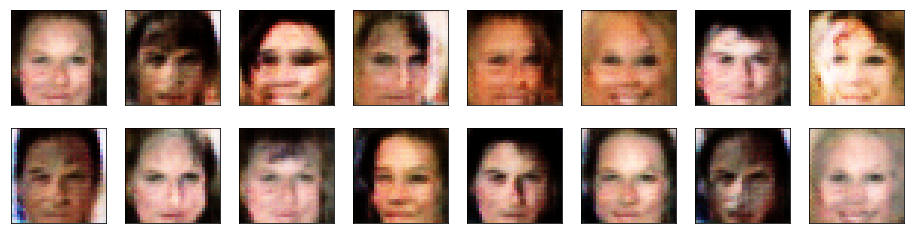

```
Epoch [    2/   50] | d_loss: 1.1019 | g_loss: 3.4432
Epoch [    2/   50] | d_loss: 0.6020 | g_loss: 1.6363
Epoch [    2/   50] | d_loss: 0.7844 | g_loss: 1.3008
Epoch [    2/   50] | d_loss: 0.8111 | g_loss: 2.0171
Epoch [    2/   50] | d_loss: 0.4688 | g_loss: 2.5176
Epoch [    2/   50] | d_loss: 0.4903 | g_loss: 2.1955
Epoch [    2/   50] | d_loss: 0.6008 | g_loss: 1.7453
Epoch [    2/   50] | d_loss: 0.8295 | g_loss: 1.2278
Epoch [    2/   50] | d_loss: 0.7639 | g_loss: 0.8921
Epoch [    2/   50] | d_loss: 0.6030 | g_loss: 2.9071
Epoch [    2/   50] | d_loss: 0.6540 | g_loss: 1.0012
Epoch [    2/   50] | d_loss: 0.7713 | g_loss: 2.0961
Epoch [    2/   50] | d_loss: 0.7358 | g_loss: 1.7528
Epoch [    2/   50] | d_loss: 0.4853 | g_loss: 1.4753
Epoch [    2/   50] | d_loss: 0.5193 | g_loss: 1.2057
Epoch [    2/   50] | d_loss: 0.3679 | g_loss: 1.8756
Epoch [    2/   50] | d_loss: 0.5819 | g_loss: 2.0251
Epoch [    2/   50] | d_loss: 0.9366 | g_loss: 1.8647
Epoch [    2/   50] | d_loss: 0.5399 | g_loss: 1.3119
Epoch [    2/   50] | d_loss: 0.5832 | g_loss: 2.3681
Epoch [    2/   50] | d_loss: 0.6998 | g_loss: 2.0424
Epoch [    2/   50] | d_loss: 0.5378 | g_loss: 2.7311
Epoch [    2/   50] | d_loss: 0.8400 | g_loss: 2.2779
Epoch [    2/   50] | d_loss: 0.4934 | g_loss: 2.5749
Epoch [    2/   50] | d_loss: 0.8036 | g_loss: 2.0087
Epoch [    2/   50] | d_loss: 1.2507 | g_loss: 1.7271
Epoch [    2/   50] | d_loss: 0.5914 | g_loss: 0.6822
Epoch [    2/   50] | d_loss: 1.1122 | g_loss: 0.3991
Epoch [    2/   50] | d_loss: 0.7158 | g_loss: 2.1653
Epoch [    3/   50] | d_loss: 0.9676 | g_loss: 3.1735
Epoch [    3/   50] | d_loss: 0.6854 | g_loss: 1.7193
Epoch [    3/   50] | d_loss: 0.7939 | g_loss: 1.9973
Epoch [    3/   50] | d_loss: 0.6314 | g_loss: 2.5626
Epoch [    3/   50] | d_loss: 0.4142 | g_loss: 2.4156
Epoch [    3/   50] | d_loss: 0.6538 | g_loss: 3.0899
Epoch [    3/   50] | d_loss: 0.4020 | g_loss: 3.7235
Epoch [    3/   50] | d_loss: 0.6103 | g_loss: 2.4026
Epoch [    3/   50] | d_loss: 0.6498 | g_loss: 1.5338
Epoch [    3/   50] | d_loss: 0.4416 | g_loss: 3.0912
Epoch [    3/   50] | d_loss: 0.4713 | g_loss: 1.8358
```

[output cut: 91 more lines]

```
Epoch [    6/   50] | d_loss: 1.0366 | g_loss: 2.3538
Epoch [    6/   50] | d_loss: 0.5896 | g_loss: 2.9548
Epoch [    6/   50] | d_loss: 0.6584 | g_loss: 0.7630
Epoch [    6/   50] | d_loss: 1.0258 | g_loss: 2.3065
Epoch [    6/   50] | d_loss: 0.3950 | g_loss: 3.2687
Epoch [    6/   50] | d_loss: 0.4153 | g_loss: 0.5599
Epoch [    6/   50] | d_loss: 0.3663 | g_loss: 3.5949
Epoch [    6/   50] | d_loss: 0.5857 | g_loss: 4.1106
Epoch [    6/   50] | d_loss: 0.3511 | g_loss: 1.8006
Epoch [    6/   50] | d_loss: 0.3753 | g_loss: 2.9802
Epoch [    6/   50] | d_loss: 0.5086 | g_loss: 1.7639
Epoch [    6/   50] | d_loss: 0.4392 | g_loss: 2.3513
Epoch [    6/   50] | d_loss: 0.5257 | g_loss: 3.8002
Epoch [    6/   50] | d_loss: 0.7661 | g_loss: 2.1556
Sample images after epoch# 5
```

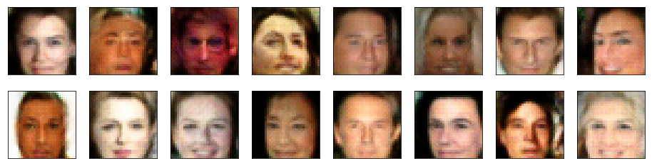

```
Epoch [    7/   50] | d_loss: 0.6957 | g_loss: 2.3964
Epoch [    7/   50] | d_loss: 0.6445 | g_loss: 1.9651
Epoch [    7/   50] | d_loss: 0.8721 | g_loss: 1.4832
Epoch [    7/   50] | d_loss: 0.5488 | g_loss: 2.7572
Epoch [    7/   50] | d_loss: 0.3617 | g_loss: 3.1258
Epoch [    7/   50] | d_loss: 0.8028 | g_loss: 2.5192
Epoch [    7/   50] | d_loss: 0.8410 | g_loss: 1.9517
Epoch [    7/   50] | d_loss: 0.7602 | g_loss: 1.4865
Epoch [    7/   50] | d_loss: 0.7499 | g_loss: 2.2717
Epoch [    7/   50] | d_loss: 0.4864 | g_loss: 4.1269
Epoch [    7/   50] | d_loss: 0.3971 | g_loss: 2.2157
Epoch [    7/   50] | d_loss: 0.3854 | g_loss: 2.0165
Epoch [    7/   50] | d_loss: 0.3982 | g_loss: 3.9099
Epoch [    7/   50] | d_loss: 1.3817 | g_loss: 1.0055
Epoch [    7/   50] | d_loss: 0.5808 | g_loss: 2.9698
Epoch [    7/   50] | d_loss: 0.4849 | g_loss: 3.2212
Epoch [    7/   50] | d_loss: 0.4841 | g_loss: 2.7307
Epoch [    7/   50] | d_loss: 0.4239 | g_loss: 2.4875
Epoch [    7/   50] | d_loss: 0.6400 | g_loss: 4.6507
Epoch [    7/   50] | d_loss: 0.3878 | g_loss: 1.9594
Epoch [    7/   50] | d_loss: 0.4530 | g_loss: 3.5049
Epoch [    7/   50] | d_loss: 0.8856 | g_loss: 3.0598
Epoch [    7/   50] | d_loss: 0.5680 | g_loss: 3.8119
Epoch [    7/   50] | d_loss: 0.3713 | g_loss: 3.0006
Epoch [    7/   50] | d_loss: 0.6066 | g_loss: 1.7362
Epoch [    7/   50] | d_loss: 0.6929 | g_loss: 2.9126
Epoch [    7/   50] | d_loss: 0.9439 | g_loss: 3.1187
Epoch [    7/   50] | d_loss: 0.6599 | g_loss: 3.5114
Epoch [    7/   50] | d_loss: 0.5849 | g_loss: 2.1906
Epoch [    8/   50] | d_loss: 0.4796 | g_loss: 2.1866
Epoch [    8/   50] | d_loss: 0.5802 | g_loss: 3.5198
Epoch [    8/   50] | d_loss: 0.7163 | g_loss: 1.0989
Epoch [    8/   50] | d_loss: 0.5697 | g_loss: 3.0663
Epoch [    8/   50] | d_loss: 0.5127 | g_loss: 3.7118
Epoch [    8/   50] | d_loss: 0.4279 | g_loss: 3.6928
Epoch [    8/   50] | d_loss: 0.6475 | g_loss: 3.9861
Epoch [    8/   50] | d_loss: 0.6398 | g_loss: 2.8188
Epoch [    8/   50] | d_loss: 0.5091 | g_loss: 2.5812
Epoch [    8/   50] | d_loss: 0.4359 | g_loss: 2.8124
Epoch [    8/   50] | d_loss: 0.3500 | g_loss: 5.1568
```

[output cut: 91 more lines]

```
Epoch [   11/   50] | d_loss: 0.5055 | g_loss: 0.4666
Epoch [   11/   50] | d_loss: 0.5498 | g_loss: 1.3496
Epoch [   11/   50] | d_loss: 0.4164 | g_loss: 4.0445
Epoch [   11/   50] | d_loss: 0.4001 | g_loss: 2.3897
Epoch [   11/   50] | d_loss: 0.4528 | g_loss: 4.1605
Epoch [   11/   50] | d_loss: 0.8024 | g_loss: 2.5212
Epoch [   11/   50] | d_loss: 0.3715 | g_loss: 3.3729
Epoch [   11/   50] | d_loss: 0.5117 | g_loss: 4.0384
Epoch [   11/   50] | d_loss: 0.3914 | g_loss: 2.5466
Epoch [   11/   50] | d_loss: 0.4154 | g_loss: 3.3463
Epoch [   11/   50] | d_loss: 0.5702 | g_loss: 5.2198
Epoch [   11/   50] | d_loss: 0.5405 | g_loss: 1.5779
Epoch [   11/   50] | d_loss: 1.3755 | g_loss: 1.5730
Epoch [   11/   50] | d_loss: 0.5572 | g_loss: 1.4686
Sample images after epoch# 10
```

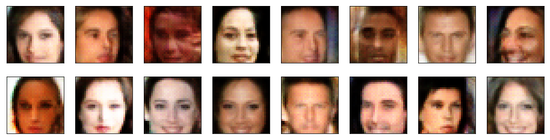

```
Epoch [   12/   50] | d_loss: 0.7963 | g_loss: 5.2715
Epoch [   12/   50] | d_loss: 0.3617 | g_loss: 2.6851
Epoch [   12/   50] | d_loss: 0.3892 | g_loss: 5.3870
Epoch [   12/   50] | d_loss: 0.4409 | g_loss: 3.7600
Epoch [   12/   50] | d_loss: 0.3550 | g_loss: 3.0943
Epoch [   12/   50] | d_loss: 0.4577 | g_loss: 4.5651
Epoch [   12/   50] | d_loss: 0.8884 | g_loss: 2.4784
Epoch [   12/   50] | d_loss: 0.5086 | g_loss: 2.5460
Epoch [   12/   50] | d_loss: 0.6785 | g_loss: 2.0651
Epoch [   12/   50] | d_loss: 0.6842 | g_loss: 3.1626
Epoch [   12/   50] | d_loss: 0.5989 | g_loss: 3.2159
Epoch [   12/   50] | d_loss: 0.5023 | g_loss: 3.3595
Epoch [   12/   50] | d_loss: 0.8597 | g_loss: 2.6401
Epoch [   12/   50] | d_loss: 0.3882 | g_loss: 1.7683
Epoch [   12/   50] | d_loss: 0.3973 | g_loss: 4.7680
Epoch [   12/   50] | d_loss: 0.6392 | g_loss: 1.8112
Epoch [   12/   50] | d_loss: 0.3781 | g_loss: 2.7594
Epoch [   12/   50] | d_loss: 0.4736 | g_loss: 4.2051
Epoch [   12/   50] | d_loss: 0.4168 | g_loss: 3.2945
Epoch [   12/   50] | d_loss: 0.4203 | g_loss: 2.0928
Epoch [   12/   50] | d_loss: 0.7877 | g_loss: 4.2575
Epoch [   12/   50] | d_loss: 0.4007 | g_loss: 4.3536
Epoch [   12/   50] | d_loss: 0.4305 | g_loss: 4.7754
Epoch [   12/   50] | d_loss: 0.7478 | g_loss: 1.1169
Epoch [   12/   50] | d_loss: 0.4870 | g_loss: 2.6533
Epoch [   12/   50] | d_loss: 0.7948 | g_loss: 3.0524
Epoch [   12/   50] | d_loss: 0.3673 | g_loss: 4.2428
Epoch [   12/   50] | d_loss: 0.4741 | g_loss: 1.6796
Epoch [   12/   50] | d_loss: 0.5186 | g_loss: 4.1910
Epoch [   13/   50] | d_loss: 0.7405 | g_loss: 2.2123
Epoch [   13/   50] | d_loss: 0.4008 | g_loss: 2.0789
Epoch [   13/   50] | d_loss: 0.4846 | g_loss: 3.3122
Epoch [   13/   50] | d_loss: 0.4721 | g_loss: 3.1320
Epoch [   13/   50] | d_loss: 0.7954 | g_loss: 2.3429
Epoch [   13/   50] | d_loss: 0.5415 | g_loss: 3.4176
Epoch [   13/   50] | d_loss: 0.5828 | g_loss: 2.5329
Epoch [   13/   50] | d_loss: 0.4978 | g_loss: 2.3646
Epoch [   13/   50] | d_loss: 0.8880 | g_loss: 3.9634
Epoch [   13/   50] | d_loss: 0.4360 | g_loss: 5.1970
Epoch [   13/   50] | d_loss: 0.4256 | g_loss: 3.2412
```

[output cut: 91 more lines]

```
Epoch [   16/   50] | d_loss: 0.3509 | g_loss: 3.0713
Epoch [   16/   50] | d_loss: 0.6081 | g_loss: 1.5175
Epoch [   16/   50] | d_loss: 0.4811 | g_loss: 2.8188
Epoch [   16/   50] | d_loss: 0.5688 | g_loss: 0.8910
Epoch [   16/   50] | d_loss: 0.4763 | g_loss: 1.8228
Epoch [   16/   50] | d_loss: 1.2947 | g_loss: 3.5966
Epoch [   16/   50] | d_loss: 0.4864 | g_loss: 2.3750
Epoch [   16/   50] | d_loss: 0.4102 | g_loss: 4.6317
Epoch [   16/   50] | d_loss: 0.4364 | g_loss: 2.0543
Epoch [   16/   50] | d_loss: 0.6931 | g_loss: 1.4047
Epoch [   16/   50] | d_loss: 0.3627 | g_loss: 2.2172
Epoch [   16/   50] | d_loss: 0.5583 | g_loss: 2.8204
Epoch [   16/   50] | d_loss: 0.4596 | g_loss: 2.6277
Epoch [   16/   50] | d_loss: 0.5394 | g_loss: 3.4130
Sample images after epoch# 15
```

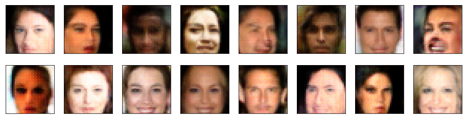

```
Epoch [   17/   50] | d_loss: 0.4444 | g_loss: 3.1052
Epoch [   17/   50] | d_loss: 0.5263 | g_loss: 2.9825
Epoch [   17/   50] | d_loss: 0.5132 | g_loss: 3.4969
Epoch [   17/   50] | d_loss: 0.4482 | g_loss: 4.4459
Epoch [   17/   50] | d_loss: 0.5600 | g_loss: 2.5634
Epoch [   17/   50] | d_loss: 0.4251 | g_loss: 2.6618
Epoch [   17/   50] | d_loss: 0.5254 | g_loss: 3.7250
Epoch [   17/   50] | d_loss: 0.4748 | g_loss: 4.9361
Epoch [   17/   50] | d_loss: 0.3921 | g_loss: 4.0053
Epoch [   17/   50] | d_loss: 0.5888 | g_loss: 2.7473
Epoch [   17/   50] | d_loss: 0.5327 | g_loss: 3.3138
Epoch [   17/   50] | d_loss: 0.4221 | g_loss: 2.8659
Epoch [   17/   50] | d_loss: 0.6239 | g_loss: 3.0152
Epoch [   17/   50] | d_loss: 0.3886 | g_loss: 2.5214
Epoch [   17/   50] | d_loss: 0.4721 | g_loss: 3.2971
Epoch [   17/   50] | d_loss: 0.6513 | g_loss: 2.2156
Epoch [   17/   50] | d_loss: 0.3552 | g_loss: 3.6155
Epoch [   17/   50] | d_loss: 1.3171 | g_loss: 3.0329
Epoch [   17/   50] | d_loss: 1.2696 | g_loss: 3.9008
Epoch [   17/   50] | d_loss: 1.2575 | g_loss: 0.8288
Epoch [   17/   50] | d_loss: 0.3622 | g_loss: 4.4917
Epoch [   17/   50] | d_loss: 0.5327 | g_loss: 4.6611
Epoch [   17/   50] | d_loss: 0.7731 | g_loss: 2.0567
Epoch [   17/   50] | d_loss: 0.3711 | g_loss: 3.4175
Epoch [   17/   50] | d_loss: 0.7282 | g_loss: 5.2727
Epoch [   17/   50] | d_loss: 0.4362 | g_loss: 2.9273
Epoch [   17/   50] | d_loss: 0.4296 | g_loss: 2.3304
Epoch [   17/   50] | d_loss: 0.3616 | g_loss: 4.0376
Epoch [   17/   50] | d_loss: 0.5839 | g_loss: 2.3925
Epoch [   18/   50] | d_loss: 1.0313 | g_loss: 3.7938
Epoch [   18/   50] | d_loss: 0.4785 | g_loss: 2.3192
Epoch [   18/   50] | d_loss: 0.3633 | g_loss: 3.4051
Epoch [   18/   50] | d_loss: 0.4713 | g_loss: 2.3455
Epoch [   18/   50] | d_loss: 0.3930 | g_loss: 4.0599
Epoch [   18/   50] | d_loss: 0.3526 | g_loss: 3.8094
Epoch [   18/   50] | d_loss: 0.4105 | g_loss: 1.5619
Epoch [   18/   50] | d_loss: 0.5222 | g_loss: 1.9668
Epoch [   18/   50] | d_loss: 0.5447 | g_loss: 4.0243
Epoch [   18/   50] | d_loss: 0.7103 | g_loss: 1.3136
Epoch [   18/   50] | d_loss: 0.4018 | g_loss: 3.3115
```

[output cut: 91 more lines]

```
Epoch [   21/   50] | d_loss: 0.3537 | g_loss: 4.3945
Epoch [   21/   50] | d_loss: 0.3680 | g_loss: 3.3918
Epoch [   21/   50] | d_loss: 0.4418 | g_loss: 2.7098
Epoch [   21/   50] | d_loss: 0.5283 | g_loss: 3.2274
Epoch [   21/   50] | d_loss: 0.7176 | g_loss: 2.7283
Epoch [   21/   50] | d_loss: 0.5761 | g_loss: 3.5883
Epoch [   21/   50] | d_loss: 0.8097 | g_loss: 2.7968
Epoch [   21/   50] | d_loss: 0.3972 | g_loss: 1.8486
Epoch [   21/   50] | d_loss: 0.3700 | g_loss: 4.9740
Epoch [   21/   50] | d_loss: 0.5123 | g_loss: 0.9920
Epoch [   21/   50] | d_loss: 0.7773 | g_loss: 1.8871
Epoch [   21/   50] | d_loss: 0.6566 | g_loss: 6.0163
Epoch [   21/   50] | d_loss: 0.7992 | g_loss: 3.2442
Epoch [   21/   50] | d_loss: 1.3856 | g_loss: 3.8807
Sample images after epoch# 20
```

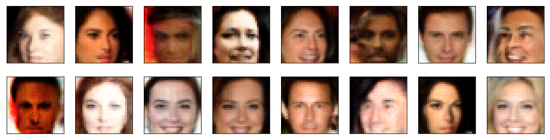

```
Epoch [   22/   50] | d_loss: 0.4734 | g_loss: 2.3942
Epoch [   22/   50] | d_loss: 0.3817 | g_loss: 3.7097
Epoch [   22/   50] | d_loss: 0.5557 | g_loss: 4.1380
Epoch [   22/   50] | d_loss: 0.5569 | g_loss: 2.8031
Epoch [   22/   50] | d_loss: 0.5308 | g_loss: 2.5435
Epoch [   22/   50] | d_loss: 0.6627 | g_loss: 1.5409
Epoch [   22/   50] | d_loss: 0.3876 | g_loss: 3.8310
Epoch [   22/   50] | d_loss: 0.4337 | g_loss: 3.2016
Epoch [   22/   50] | d_loss: 0.4267 | g_loss: 3.7925
Epoch [   22/   50] | d_loss: 0.6001 | g_loss: 2.3850
Epoch [   22/   50] | d_loss: 0.5604 | g_loss: 7.5116
Epoch [   22/   50] | d_loss: 0.3544 | g_loss: 3.1467
Epoch [   22/   50] | d_loss: 0.4443 | g_loss: 3.5408
Epoch [   22/   50] | d_loss: 0.4419 | g_loss: 2.0058
Epoch [   22/   50] | d_loss: 0.3763 | g_loss: 2.8768
Epoch [   22/   50] | d_loss: 0.9155 | g_loss: 4.2573
Epoch [   22/   50] | d_loss: 0.4163 | g_loss: 2.2214
Epoch [   22/   50] | d_loss: 0.4641 | g_loss: 4.9047
Epoch [   22/   50] | d_loss: 0.4661 | g_loss: 1.3407
Epoch [   22/   50] | d_loss: 0.6415 | g_loss: 4.2678
Epoch [   22/   50] | d_loss: 0.4686 | g_loss: 4.2835
Epoch [   22/   50] | d_loss: 0.5082 | g_loss: 3.7178
Epoch [   22/   50] | d_loss: 0.4349 | g_loss: 3.7257
Epoch [   22/   50] | d_loss: 0.3899 | g_loss: 2.6728
Epoch [   22/   50] | d_loss: 0.4706 | g_loss: 1.5455
Epoch [   22/   50] | d_loss: 0.4088 | g_loss: 3.4142
Epoch [   22/   50] | d_loss: 0.4090 | g_loss: 3.6896
Epoch [   22/   50] | d_loss: 0.4175 | g_loss: 2.5254
Epoch [   22/   50] | d_loss: 0.4288 | g_loss: 4.6004
Epoch [   23/   50] | d_loss: 0.3716 | g_loss: 3.5424
Epoch [   23/   50] | d_loss: 0.4222 | g_loss: 1.4283
Epoch [   23/   50] | d_loss: 0.4076 | g_loss: 3.2248
Epoch [   23/   50] | d_loss: 0.3910 | g_loss: 1.4274
Epoch [   23/   50] | d_loss: 0.4825 | g_loss: 4.9171
Epoch [   23/   50] | d_loss: 2.0167 | g_loss: 1.4773
Epoch [   23/   50] | d_loss: 0.3504 | g_loss: 4.0948
Epoch [   23/   50] | d_loss: 0.6475 | g_loss: 2.3003
Epoch [   23/   50] | d_loss: 0.6134 | g_loss: 4.3145
Epoch [   23/   50] | d_loss: 0.6386 | g_loss: 1.9766
Epoch [   23/   50] | d_loss: 0.4656 | g_loss: 3.9710
```

[output cut: 91 more lines]

```
Epoch [   26/   50] | d_loss: 0.5527 | g_loss: 2.9256
Epoch [   26/   50] | d_loss: 0.4850 | g_loss: 2.9308
Epoch [   26/   50] | d_loss: 0.5294 | g_loss: 2.8394
Epoch [   26/   50] | d_loss: 0.3945 | g_loss: 4.1549
Epoch [   26/   50] | d_loss: 0.5221 | g_loss: 2.7153
Epoch [   26/   50] | d_loss: 0.3837 | g_loss: 4.1516
Epoch [   26/   50] | d_loss: 0.4838 | g_loss: 3.4481
Epoch [   26/   50] | d_loss: 0.5352 | g_loss: 2.3905
Epoch [   26/   50] | d_loss: 0.4612 | g_loss: 5.4095
Epoch [   26/   50] | d_loss: 0.3488 | g_loss: 4.9423
Epoch [   26/   50] | d_loss: 0.3691 | g_loss: 3.8610
Epoch [   26/   50] | d_loss: 0.4006 | g_loss: 2.5774
Epoch [   26/   50] | d_loss: 0.6011 | g_loss: 2.5653
Epoch [   26/   50] | d_loss: 0.7810 | g_loss: 3.4834
Sample images after epoch# 25
```

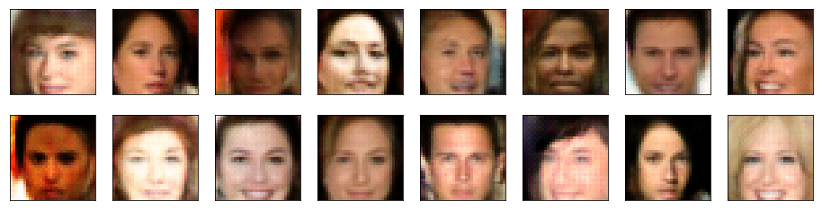

```
Epoch [   27/   50] | d_loss: 0.7862 | g_loss: 2.6591
Epoch [   27/   50] | d_loss: 0.3868 | g_loss: 2.6033
Epoch [   27/   50] | d_loss: 0.3679 | g_loss: 1.4754
Epoch [   27/   50] | d_loss: 0.7078 | g_loss: 3.9874
Epoch [   27/   50] | d_loss: 0.5581 | g_loss: 1.6836
Epoch [   27/   50] | d_loss: 0.4330 | g_loss: 3.1505
Epoch [   27/   50] | d_loss: 0.6698 | g_loss: 0.6729
Epoch [   27/   50] | d_loss: 0.4108 | g_loss: 2.6690
Epoch [   27/   50] | d_loss: 0.4763 | g_loss: 3.4370
Epoch [   27/   50] | d_loss: 0.5189 | g_loss: 3.8965
Epoch [   27/   50] | d_loss: 0.3863 | g_loss: 3.6393
Epoch [   27/   50] | d_loss: 0.8434 | g_loss: 3.4917
Epoch [   27/   50] | d_loss: 0.5292 | g_loss: 2.3017
Epoch [   27/   50] | d_loss: 0.3938 | g_loss: 2.2760
Epoch [   27/   50] | d_loss: 0.3676 | g_loss: 2.6475
Epoch [   27/   50] | d_loss: 0.3750 | g_loss: 5.6696
Epoch [   27/   50] | d_loss: 0.4490 | g_loss: 1.9696
Epoch [   27/   50] | d_loss: 0.6612 | g_loss: 3.6494
Epoch [   27/   50] | d_loss: 1.0039 | g_loss: 1.1407
Epoch [   27/   50] | d_loss: 0.4373 | g_loss: 3.1758
Epoch [   27/   50] | d_loss: 0.3886 | g_loss: 3.4437
Epoch [   27/   50] | d_loss: 0.4879 | g_loss: 2.5486
Epoch [   27/   50] | d_loss: 0.6583 | g_loss: 2.0895
Epoch [   27/   50] | d_loss: 0.3756 | g_loss: 1.7910
Epoch [   27/   50] | d_loss: 0.4890 | g_loss: 2.8634
Epoch [   27/   50] | d_loss: 0.3927 | g_loss: 2.0783
Epoch [   27/   50] | d_loss: 0.4213 | g_loss: 4.1742
Epoch [   27/   50] | d_loss: 0.3970 | g_loss: 4.5537
Epoch [   27/   50] | d_loss: 0.3825 | g_loss: 3.4501
Epoch [   28/   50] | d_loss: 0.3466 | g_loss: 5.3270
Epoch [   28/   50] | d_loss: 0.3854 | g_loss: 2.1538
Epoch [   28/   50] | d_loss: 0.6187 | g_loss: 3.2159
Epoch [   28/   50] | d_loss: 0.3621 | g_loss: 3.4752
Epoch [   28/   50] | d_loss: 0.4241 | g_loss: 5.5655
Epoch [   28/   50] | d_loss: 0.5130 | g_loss: 2.6697
Epoch [   28/   50] | d_loss: 0.4521 | g_loss: 4.0581
Epoch [   28/   50] | d_loss: 0.4170 | g_loss: 3.0988
Epoch [   28/   50] | d_loss: 0.3565 | g_loss: 2.6760
Epoch [   28/   50] | d_loss: 0.4113 | g_loss: 3.3081
Epoch [   28/   50] | d_loss: 1.4521 | g_loss: 0.5376
```

[output cut: 91 more lines]

```
Epoch [   31/   50] | d_loss: 0.4145 | g_loss: 3.1568
Epoch [   31/   50] | d_loss: 0.5711 | g_loss: 4.3020
Epoch [   31/   50] | d_loss: 0.4239 | g_loss: 3.6266
Epoch [   31/   50] | d_loss: 0.5714 | g_loss: 2.3359
Epoch [   31/   50] | d_loss: 0.6675 | g_loss: 2.5751
Epoch [   31/   50] | d_loss: 0.8966 | g_loss: 3.9108
Epoch [   31/   50] | d_loss: 0.5629 | g_loss: 2.8702
Epoch [   31/   50] | d_loss: 0.6835 | g_loss: 4.7190
Epoch [   31/   50] | d_loss: 0.3811 | g_loss: 2.6933
Epoch [   31/   50] | d_loss: 0.4703 | g_loss: 5.9399
Epoch [   31/   50] | d_loss: 0.3505 | g_loss: 2.9488
Epoch [   31/   50] | d_loss: 0.6204 | g_loss: 1.9124
Epoch [   31/   50] | d_loss: 0.3888 | g_loss: 5.4618
Epoch [   31/   50] | d_loss: 0.7427 | g_loss: 3.3523
Sample images after epoch# 30
```

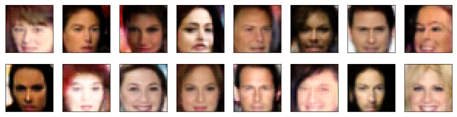

```
Epoch [   32/   50] | d_loss: 0.8924 | g_loss: 4.6392
Epoch [   32/   50] | d_loss: 0.4057 | g_loss: 5.4662
Epoch [   32/   50] | d_loss: 0.4390 | g_loss: 4.0284
Epoch [   32/   50] | d_loss: 0.4344 | g_loss: 2.8508
Epoch [   32/   50] | d_loss: 0.4184 | g_loss: 1.1679
Epoch [   32/   50] | d_loss: 0.3511 | g_loss: 3.9159
Epoch [   32/   50] | d_loss: 0.3950 | g_loss: 4.5083
Epoch [   32/   50] | d_loss: 0.3740 | g_loss: 5.5540
Epoch [   32/   50] | d_loss: 0.3823 | g_loss: 3.3499
Epoch [   32/   50] | d_loss: 0.7845 | g_loss: 3.9576
Epoch [   32/   50] | d_loss: 0.3730 | g_loss: 1.7419
Epoch [   32/   50] | d_loss: 0.3617 | g_loss: 3.6734
Epoch [   32/   50] | d_loss: 0.5278 | g_loss: 4.2816
Epoch [   32/   50] | d_loss: 1.3100 | g_loss: 5.4958
Epoch [   32/   50] | d_loss: 0.4071 | g_loss: 2.4185
Epoch [   32/   50] | d_loss: 0.3674 | g_loss: 3.8202
Epoch [   32/   50] | d_loss: 0.4550 | g_loss: 4.8230
Epoch [   32/   50] | d_loss: 0.3562 | g_loss: 3.7338
Epoch [   32/   50] | d_loss: 0.3508 | g_loss: 4.6937
Epoch [   32/   50] | d_loss: 0.3918 | g_loss: 4.8130
Epoch [   32/   50] | d_loss: 0.4701 | g_loss: 3.7824
Epoch [   32/   50] | d_loss: 0.8199 | g_loss: 2.7674
Epoch [   32/   50] | d_loss: 0.3627 | g_loss: 3.3221
Epoch [   32/   50] | d_loss: 0.3997 | g_loss: 1.7114
Epoch [   32/   50] | d_loss: 0.4317 | g_loss: 2.4898
Epoch [   32/   50] | d_loss: 0.3892 | g_loss: 5.6108
Epoch [   32/   50] | d_loss: 0.5826 | g_loss: 4.2929
Epoch [   32/   50] | d_loss: 0.6241 | g_loss: 2.0502
Epoch [   32/   50] | d_loss: 0.4774 | g_loss: 3.6844
Epoch [   33/   50] | d_loss: 0.3926 | g_loss: 2.5562
Epoch [   33/   50] | d_loss: 0.4675 | g_loss: 3.3980
Epoch [   33/   50] | d_loss: 0.4576 | g_loss: 1.9737
Epoch [   33/   50] | d_loss: 0.3679 | g_loss: 2.6643
Epoch [   33/   50] | d_loss: 0.4354 | g_loss: 3.4218
Epoch [   33/   50] | d_loss: 0.3699 | g_loss: 4.4303
Epoch [   33/   50] | d_loss: 0.3958 | g_loss: 3.1820
Epoch [   33/   50] | d_loss: 0.5352 | g_loss: 7.0897
Epoch [   33/   50] | d_loss: 0.3992 | g_loss: 4.6568
Epoch [   33/   50] | d_loss: 0.3705 | g_loss: 3.2696
Epoch [   33/   50] | d_loss: 0.3699 | g_loss: 4.9013
```

[output cut: 91 more lines]

```
Epoch [   36/   50] | d_loss: 0.4688 | g_loss: 2.8295
Epoch [   36/   50] | d_loss: 0.3868 | g_loss: 2.0043
Epoch [   36/   50] | d_loss: 0.3755 | g_loss: 2.6606
Epoch [   36/   50] | d_loss: 0.3724 | g_loss: 2.4455
Epoch [   36/   50] | d_loss: 0.5422 | g_loss: 1.7642
Epoch [   36/   50] | d_loss: 0.3848 | g_loss: 3.8710
Epoch [   36/   50] | d_loss: 0.6070 | g_loss: 2.0411
Epoch [   36/   50] | d_loss: 0.4784 | g_loss: 4.2209
Epoch [   36/   50] | d_loss: 0.3726 | g_loss: 6.4201
Epoch [   36/   50] | d_loss: 0.3452 | g_loss: 3.5305
Epoch [   36/   50] | d_loss: 0.4063 | g_loss: 3.2552
Epoch [   36/   50] | d_loss: 0.4509 | g_loss: 3.7250
Epoch [   36/   50] | d_loss: 0.5958 | g_loss: 3.0579
Epoch [   36/   50] | d_loss: 0.4171 | g_loss: 3.4090
Sample images after epoch# 35
```

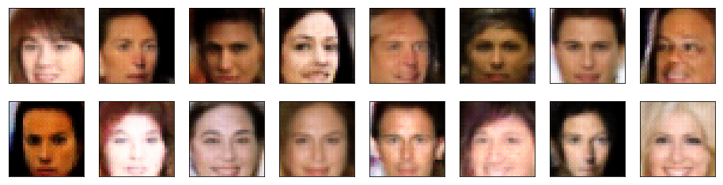

```
Epoch [   37/   50] | d_loss: 0.3658 | g_loss: 3.2518
Epoch [   37/   50] | d_loss: 0.4621 | g_loss: 2.6695
Epoch [   37/   50] | d_loss: 0.3824 | g_loss: 5.5081
Epoch [   37/   50] | d_loss: 0.8784 | g_loss: 4.1270
Epoch [   37/   50] | d_loss: 0.9741 | g_loss: 4.0680
Epoch [   37/   50] | d_loss: 0.4906 | g_loss: 1.8177
Epoch [   37/   50] | d_loss: 0.7591 | g_loss: 3.0116
Epoch [   37/   50] | d_loss: 0.4871 | g_loss: 1.7640
Epoch [   37/   50] | d_loss: 0.4208 | g_loss: 2.8699
Epoch [   37/   50] | d_loss: 0.3764 | g_loss: 3.2312
Epoch [   37/   50] | d_loss: 0.4286 | g_loss: 1.6688
Epoch [   37/   50] | d_loss: 0.7116 | g_loss: 3.4821
Epoch [   37/   50] | d_loss: 0.4572 | g_loss: 5.6617
Epoch [   37/   50] | d_loss: 0.3695 | g_loss: 2.5293
Epoch [   37/   50] | d_loss: 0.4381 | g_loss: 1.0315
Epoch [   37/   50] | d_loss: 0.3858 | g_loss: 1.7327
Epoch [   37/   50] | d_loss: 0.5222 | g_loss: 2.5020
Epoch [   37/   50] | d_loss: 0.3621 | g_loss: 3.7286
Epoch [   37/   50] | d_loss: 0.3945 | g_loss: 4.0530
Epoch [   37/   50] | d_loss: 0.5110 | g_loss: 2.0234
Epoch [   37/   50] | d_loss: 0.8618 | g_loss: 6.7769
Epoch [   37/   50] | d_loss: 0.3809 | g_loss: 4.4695
Epoch [   37/   50] | d_loss: 0.3884 | g_loss: 1.6018
Epoch [   37/   50] | d_loss: 0.3976 | g_loss: 3.1300
Epoch [   37/   50] | d_loss: 0.4260 | g_loss: 2.3562
Epoch [   37/   50] | d_loss: 0.3846 | g_loss: 3.4408
Epoch [   37/   50] | d_loss: 0.4071 | g_loss: 2.6042
Epoch [   37/   50] | d_loss: 1.5228 | g_loss: 2.6159
Epoch [   37/   50] | d_loss: 0.4893 | g_loss: 5.3059
Epoch [   38/   50] | d_loss: 0.4080 | g_loss: 2.0590
Epoch [   38/   50] | d_loss: 0.4204 | g_loss: 4.6852
Epoch [   38/   50] | d_loss: 0.3411 | g_loss: 3.7744
Epoch [   38/   50] | d_loss: 0.4774 | g_loss: 4.0572
Epoch [   38/   50] | d_loss: 0.3627 | g_loss: 3.4159
Epoch [   38/   50] | d_loss: 0.7093 | g_loss: 3.8354
Epoch [   38/   50] | d_loss: 0.5174 | g_loss: 4.1930
Epoch [   38/   50] | d_loss: 0.5136 | g_loss: 4.5034
Epoch [   38/   50] | d_loss: 0.8794 | g_loss: 5.5443
Epoch [   38/   50] | d_loss: 0.8118 | g_loss: 3.7602
Epoch [   38/   50] | d_loss: 0.3979 | g_loss: 3.8167
```

[output cut: 91 more lines]

```
Epoch [   41/   50] | d_loss: 0.5601 | g_loss: 4.8259
Epoch [   41/   50] | d_loss: 0.3670 | g_loss: 2.5716
Epoch [   41/   50] | d_loss: 0.4288 | g_loss: 4.4356
Epoch [   41/   50] | d_loss: 0.4217 | g_loss: 7.6083
Epoch [   41/   50] | d_loss: 0.3860 | g_loss: 3.9625
Epoch [   41/   50] | d_loss: 0.3680 | g_loss: 3.2482
Epoch [   41/   50] | d_loss: 0.3829 | g_loss: 5.4347
Epoch [   41/   50] | d_loss: 0.3848 | g_loss: 4.0380
Epoch [   41/   50] | d_loss: 0.6549 | g_loss: 6.2893
Epoch [   41/   50] | d_loss: 0.4463 | g_loss: 4.8601
Epoch [   41/   50] | d_loss: 0.3596 | g_loss: 2.7719
Epoch [   41/   50] | d_loss: 0.5139 | g_loss: 3.5061
Epoch [   41/   50] | d_loss: 0.3590 | g_loss: 4.5538
Epoch [   41/   50] | d_loss: 0.6315 | g_loss: 3.3893
Sample images after epoch# 40
```

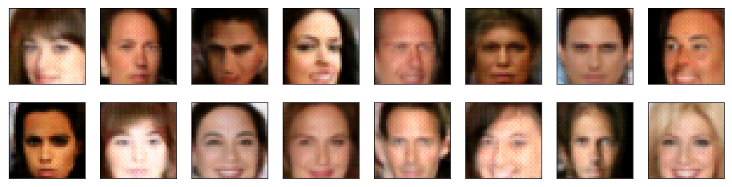

```
Epoch [   42/   50] | d_loss: 0.5259 | g_loss: 2.9365
Epoch [   42/   50] | d_loss: 0.5472 | g_loss: 1.4425
Epoch [   42/   50] | d_loss: 0.4639 | g_loss: 3.0090
Epoch [   42/   50] | d_loss: 0.4255 | g_loss: 2.1245
Epoch [   42/   50] | d_loss: 0.3396 | g_loss: 3.0978
Epoch [   42/   50] | d_loss: 1.4631 | g_loss: 8.1089
Epoch [   42/   50] | d_loss: 0.4501 | g_loss: 1.5432
Epoch [   42/   50] | d_loss: 0.5497 | g_loss: 3.4421
Epoch [   42/   50] | d_loss: 0.3735 | g_loss: 5.0916
Epoch [   42/   50] | d_loss: 0.4799 | g_loss: 2.5235
Epoch [   42/   50] | d_loss: 0.3996 | g_loss: 3.2245
Epoch [   42/   50] | d_loss: 0.6434 | g_loss: 1.3059
Epoch [   42/   50] | d_loss: 0.8090 | g_loss: 3.5299
Epoch [   42/   50] | d_loss: 0.3742 | g_loss: 3.4047
Epoch [   42/   50] | d_loss: 0.3734 | g_loss: 4.9040
Epoch [   42/   50] | d_loss: 0.3653 | g_loss: 2.5679
Epoch [   42/   50] | d_loss: 0.3771 | g_loss: 7.3741
Epoch [   42/   50] | d_loss: 0.3625 | g_loss: 5.0554
Epoch [   42/   50] | d_loss: 0.4830 | g_loss: 5.5914
Epoch [   42/   50] | d_loss: 0.6668 | g_loss: 1.9022
Epoch [   42/   50] | d_loss: 0.3512 | g_loss: 1.7857
Epoch [   42/   50] | d_loss: 0.3950 | g_loss: 3.4430
Epoch [   42/   50] | d_loss: 0.3788 | g_loss: 6.1602
Epoch [   42/   50] | d_loss: 0.4274 | g_loss: 5.4799
Epoch [   42/   50] | d_loss: 0.6650 | g_loss: 4.3614
Epoch [   42/   50] | d_loss: 0.7233 | g_loss: 4.2604
Epoch [   42/   50] | d_loss: 0.4088 | g_loss: 3.9878
Epoch [   42/   50] | d_loss: 0.4765 | g_loss: 4.8580
Epoch [   42/   50] | d_loss: 0.5770 | g_loss: 2.9141
Epoch [   43/   50] | d_loss: 0.5811 | g_loss: 4.8157
Epoch [   43/   50] | d_loss: 0.3523 | g_loss: 3.4795
Epoch [   43/   50] | d_loss: 0.4275 | g_loss: 2.7575
Epoch [   43/   50] | d_loss: 0.3944 | g_loss: 3.4235
Epoch [   43/   50] | d_loss: 0.3920 | g_loss: 1.4680
Epoch [   43/   50] | d_loss: 0.3496 | g_loss: 6.7560
Epoch [   43/   50] | d_loss: 0.3674 | g_loss: 4.8972
Epoch [   43/   50] | d_loss: 0.4333 | g_loss: 4.4019
Epoch [   43/   50] | d_loss: 0.3617 | g_loss: 3.8009
Epoch [   43/   50] | d_loss: 0.4261 | g_loss: 2.4900
Epoch [   43/   50] | d_loss: 0.4250 | g_loss: 3.6720
```

[output cut: 91 more lines]

```
Epoch [   46/   50] | d_loss: 1.4707 | g_loss: 0.4674
Epoch [   46/   50] | d_loss: 0.4103 | g_loss: 4.0846
Epoch [   46/   50] | d_loss: 0.4339 | g_loss: 4.5833
Epoch [   46/   50] | d_loss: 0.6972 | g_loss: 1.8973
Epoch [   46/   50] | d_loss: 0.3369 | g_loss: 5.8955
Epoch [   46/   50] | d_loss: 0.3880 | g_loss: 5.0555
Epoch [   46/   50] | d_loss: 0.3868 | g_loss: 2.1451
Epoch [   46/   50] | d_loss: 0.4042 | g_loss: 4.9531
Epoch [   46/   50] | d_loss: 0.6218 | g_loss: 2.9134
Epoch [   46/   50] | d_loss: 0.5067 | g_loss: 2.6364
Epoch [   46/   50] | d_loss: 0.4370 | g_loss: 4.5584
Epoch [   46/   50] | d_loss: 0.6880 | g_loss: 6.1232
Epoch [   46/   50] | d_loss: 0.8275 | g_loss: 5.3697
Epoch [   46/   50] | d_loss: 0.3808 | g_loss: 3.1623
Sample images after epoch# 45
```

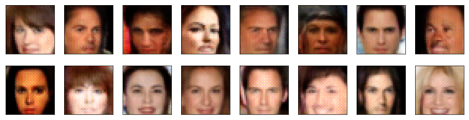

```
Epoch [   47/   50] | d_loss: 0.3781 | g_loss: 4.2588
Epoch [   47/   50] | d_loss: 0.4864 | g_loss: 2.5233
Epoch [   47/   50] | d_loss: 0.3496 | g_loss: 4.8839
Epoch [   47/   50] | d_loss: 0.3900 | g_loss: 1.8825
Epoch [   47/   50] | d_loss: 0.6739 | g_loss: 5.0870
Epoch [   47/   50] | d_loss: 0.3729 | g_loss: 3.3946
Epoch [   47/   50] | d_loss: 0.9572 | g_loss: 4.9582
Epoch [   47/   50] | d_loss: 0.4253 | g_loss: 2.5816
Epoch [   47/   50] | d_loss: 0.3909 | g_loss: 3.7262
Epoch [   47/   50] | d_loss: 0.4492 | g_loss: 2.0253
Epoch [   47/   50] | d_loss: 0.6565 | g_loss: 3.8820
Epoch [   47/   50] | d_loss: 0.3564 | g_loss: 3.3716
Epoch [   47/   50] | d_loss: 1.1412 | g_loss: 1.0930
Epoch [   47/   50] | d_loss: 0.5272 | g_loss: 2.7765
Epoch [   47/   50] | d_loss: 0.3658 | g_loss: 4.5879
Epoch [   47/   50] | d_loss: 0.9312 | g_loss: 3.3390
Epoch [   47/   50] | d_loss: 0.3505 | g_loss: 5.0236
Epoch [   47/   50] | d_loss: 0.5468 | g_loss: 3.8544
Epoch [   47/   50] | d_loss: 0.4562 | g_loss: 0.8732
Epoch [   47/   50] | d_loss: 0.3847 | g_loss: 5.3836
Epoch [   47/   50] | d_loss: 0.4258 | g_loss: 4.4417
Epoch [   47/   50] | d_loss: 0.3625 | g_loss: 4.5370
Epoch [   47/   50] | d_loss: 0.3663 | g_loss: 4.9471
Epoch [   47/   50] | d_loss: 0.3721 | g_loss: 3.0444
Epoch [   47/   50] | d_loss: 0.6554 | g_loss: 3.4838
Epoch [   47/   50] | d_loss: 0.3468 | g_loss: 4.4984
Epoch [   47/   50] | d_loss: 0.3532 | g_loss: 2.8176
Epoch [   47/   50] | d_loss: 0.6749 | g_loss: 2.4461
Epoch [   47/   50] | d_loss: 0.3576 | g_loss: 3.5311
Epoch [   48/   50] | d_loss: 0.4501 | g_loss: 3.7820
Epoch [   48/   50] | d_loss: 0.5370 | g_loss: 3.1543
Epoch [   48/   50] | d_loss: 0.5126 | g_loss: 4.7973
Epoch [   48/   50] | d_loss: 0.4986 | g_loss: 2.2444
Epoch [   48/   50] | d_loss: 0.7109 | g_loss: 3.9612
Epoch [   48/   50] | d_loss: 0.5227 | g_loss: 3.0827
Epoch [   48/   50] | d_loss: 1.4484 | g_loss: 2.6381
Epoch [   48/   50] | d_loss: 0.5001 | g_loss: 3.9955
Epoch [   48/   50] | d_loss: 0.3990 | g_loss: 3.8169
Epoch [   48/   50] | d_loss: 0.3686 | g_loss: 3.4319
Epoch [   48/   50] | d_loss: 0.3739 | g_loss: 3.2320
```

[output cut: 61 more lines]

```
Epoch [   50/   50] | d_loss: 0.3660 | g_loss: 6.7380
Epoch [   50/   50] | d_loss: 0.4075 | g_loss: 4.6478
Epoch [   50/   50] | d_loss: 0.3639 | g_loss: 3.4616
Epoch [   50/   50] | d_loss: 0.3730 | g_loss: 2.7453
Epoch [   50/   50] | d_loss: 0.5917 | g_loss: 1.1990
Epoch [   50/   50] | d_loss: 0.5458 | g_loss: 2.6189
Epoch [   50/   50] | d_loss: 0.5345 | g_loss: 2.7172
Epoch [   50/   50] | d_loss: 0.6427 | g_loss: 4.4229
Epoch [   50/   50] | d_loss: 0.5693 | g_loss: 0.8832
Epoch [   50/   50] | d_loss: 0.3881 | g_loss: 4.3608
Epoch [   50/   50] | d_loss: 0.4112 | g_loss: 5.4207
Epoch [   50/   50] | d_loss: 0.3970 | g_loss: 2.5935
Epoch [   50/   50] | d_loss: 0.3566 | g_loss: 3.8695
Epoch [   50/   50] | d_loss: 0.3655 | g_loss: 4.5404
Epoch [   50/   50] | d_loss: 0.3647 | g_loss: 2.2080
```

```python
# set number of epochs
n_epochs = 50

with active_session():
    """
    DON'T MODIFY ANYTHING IN THIS CELL
    """
    # call training function
    losses = train(D, G, n_epochs=n_epochs)
```

## Training loss

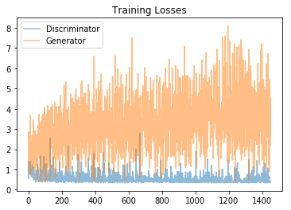

```python
fig, ax = plt.subplots()
losses = np.array(losses)
plt.plot(losses.T[0], label='Discriminator', alpha=0.5)
plt.plot(losses.T[1], label='Generator', alpha=0.5)
plt.title("Training Losses")
plt.legend()
```

## Generator samples from training

View samples of images from the generator, and answer a question about the strengths and weaknesses of your trained models.

```python
# helper function for viewing a list of passed in sample images
def view_samples(epoch, samples):
    fig, axes = plt.subplots(figsize=(16,4), nrows=2, ncols=8, sharey=True, sharex=True)
    for ax, img in zip(axes.flatten(), samples[epoch]):
        img = img.detach().cpu().numpy()
        img = np.transpose(img, (1, 2, 0))
        img = ((img + 1)*255 / (2)).astype(np.uint8)
        ax.xaxis.set_visible(False)
        ax.yaxis.set_visible(False)
        im = ax.imshow(img.reshape((32,32,3)))
```

```python
# Load samples from generator, taken while training
with open('train_samples.pkl', 'rb') as f:
    samples = pkl.load(f)
```

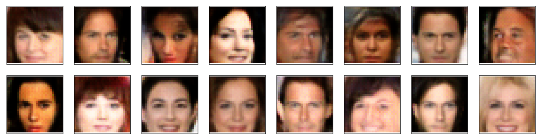

```python
_ = view_samples(-1, samples)
```

### Question: What do you notice about your generated samples and how might you improve this model?

When you answer this question, consider the following factors:

- The dataset is biased; it is made of "celebrity" faces that are mostly white
- Model size; larger models have the opportunity to learn more features in a data feature space
- Optimization strategy; optimizers and number of epochs affect your final result

**Answer:** I have tried the following: dropout in both D and G, different batch_size/lr, label smoothing, lower beta1 to [0.1,0.3], changing the CNN architecture, and adding noise to the discriminator input. Getting the right hyperparameters requires alot exploration and the competition between the discriminator and generator is not conveging easily.

### Submitting This Project

When submitting this project, make sure to run all the cells before saving the notebook. Save the notebook file as "dlnd_face_generation.ipynb" and save it as a HTML file under "File" -> "Download as". Include the "problem_unittests.py" files in your submission.